# HW3 - Forecasting

Rachel Greenlee

2/18/2022

**Exercises from Section 5 of Forecasting: Principles & Practice at https://otexts.com/fpp3/toolbox-exercises.html**

### Exercise 5.1

#### Produce forecasts for the following series using whichever of NAIVE(y), SNAIVE(y) or RW(y ~ drift()) is more appropriate in each case:

#### Australian Population (global_economy)

A quick plot of the data shows a fairly linear upward trend. In this case I believe a drift forecast is most appropriate as it will capture the upward trajectory more than the other methods.

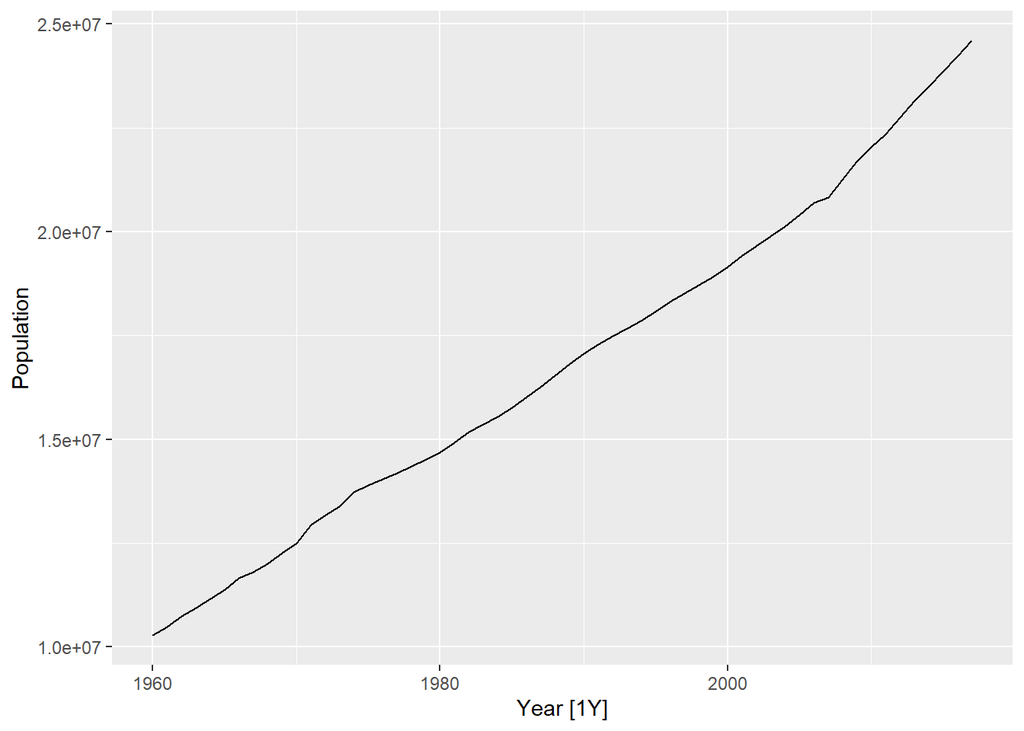

```r
global_economy %>%
  filter(Country == "Australia") %>%
  autoplot(Population)
```

After creating the random walk/drift model and forecasting 20 years, I plot the original data with the forecast, which also shows the confidence intervals in darker/lighter shades of blue.

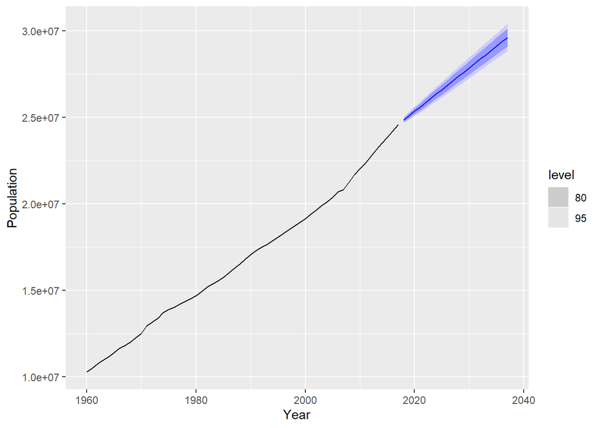

```r
global_economy %>%
  filter(Country == "Australia") %>%
  model(RW(Population ~ drift())) %>%
  forecast(h = 20) %>%
  autoplot(global_economy)
```

#### Bricks (aus_production)

As the plot of the raw data below shows, there is a seasonal pattern to this data so a seasonal naive method might be best.

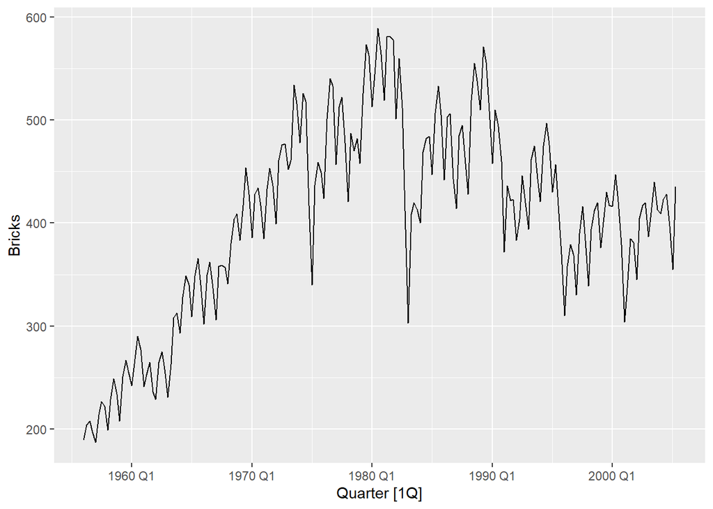

```r
#remove any rows with NA in Bricks variable
aus_bricks <- aus_production %>%
  filter(!is.na(Bricks))

#plot
aus_bricks %>%
  autoplot(Bricks)
```

Below we see and addition 3 years (12 quarters) worth of forecaster data which incorporates the seasonality of this data, but not much else in terms of trend.

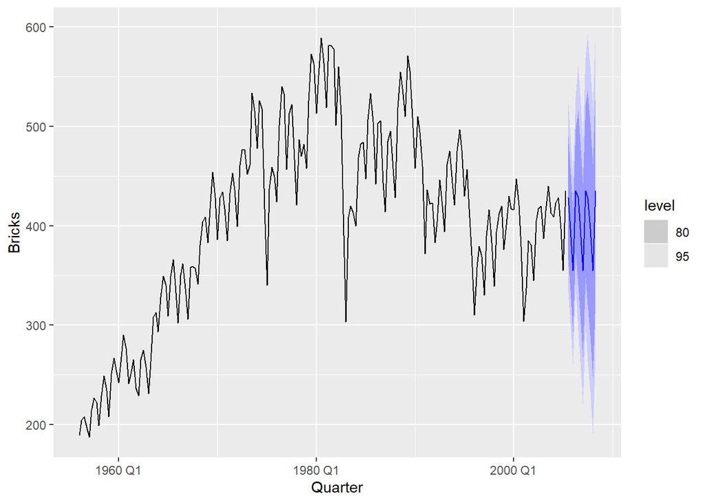

```r
#note this code wouldn't generate forecast when NAs remained in Bricks
aus_bricks %>%
  model(SNAIVE(Bricks ~ lag("year"))) %>%
  forecast(h = 12) %>%
  autoplot(aus_bricks)
```

#### NSW Lambs (aus_livestock)

After filtering the data I plot the raw count data and produce a gg_lag plot checking for any seasonality. None of the lag plot increments (1 through 12 months) seem very tight - so I’ll choose the naive forecasting method.

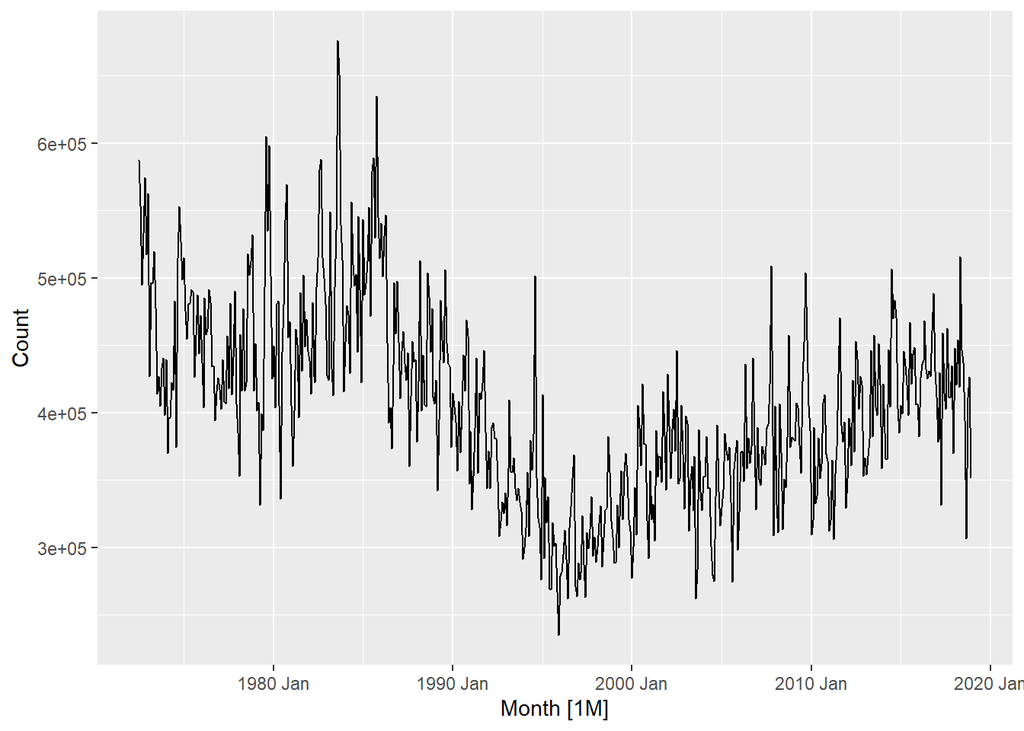

```r
aus_livestock %>%
  filter(State == "New South Wales",
         Animal == "Lambs") %>%
  autoplot(Count)
```

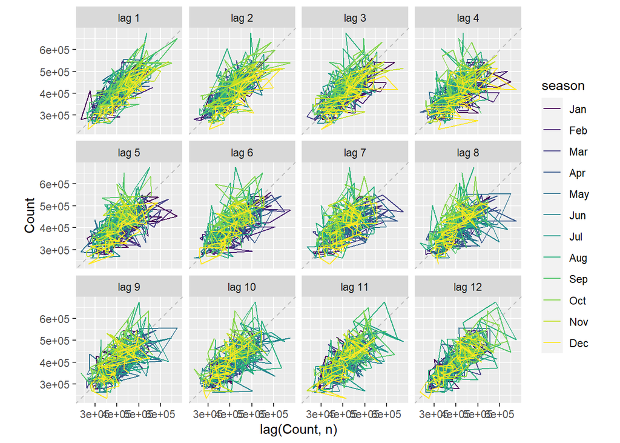

```r
aus_livestock %>%
  filter(State == "New South Wales",
         Animal == "Lambs") %>%
  gg_lag(lags = 1:12)
```

Below we see the forecast data for the next 3 years (36 months) is simply the most recent value, with decreasing confidence (widening intervals) as the forecast goes further into the future.

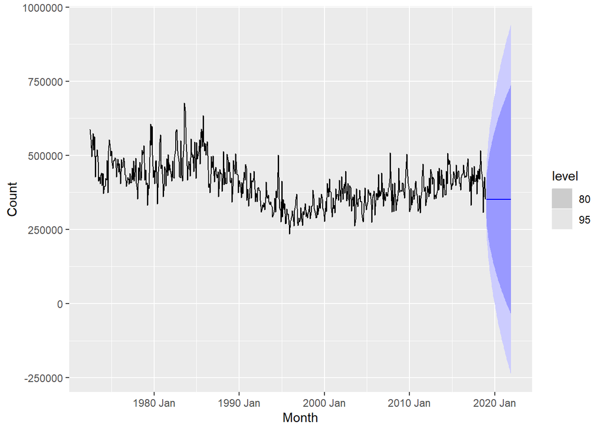

```r
aus_livestock %>%
  filter(State == "New South Wales",
         Animal == "Lambs") %>%
  model(NAIVE(Count)) %>%
  forecast(h = 36) %>%
  autoplot(aus_livestock)
```

#### Household wealth (hh_budget)

I presume this follows the theme that I should filter for the Australian data. The raw data does not appear to have seasonality but dose have some changes in trend. As there is no seasonality or strong trend, a naive method is best again.

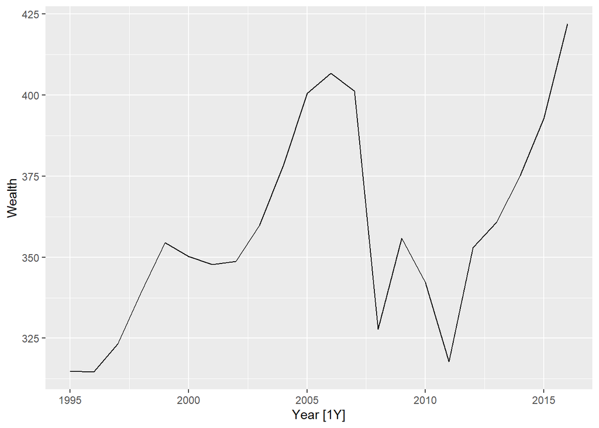

```r
hh_budget %>%
  filter(Country == "Australia") %>%
  autoplot(Wealth)
```

Below a forecast for the next 5 years is plotted, which is simply the most recent value in the historical data.

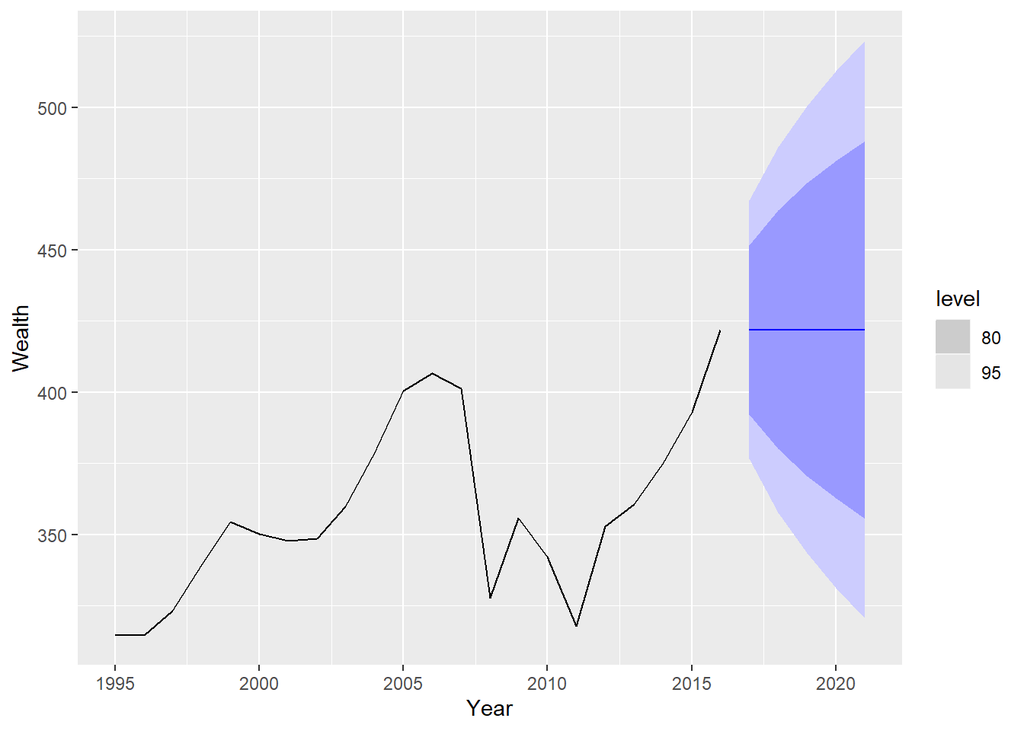

```r
hh_budget %>%
  filter(Country == "Australia") %>%
  model(NAIVE(Wealth)) %>%
  forecast(h = 5) %>%
  autoplot(hh_budget)
```

#### Australian takeaway food turnover (aus_retail)

After filtering for takeaway food services and choosing Queensland as the data to experiment with, I plot the raw values. I check for seasonality with a lag plot again. There does appear to be some seasonality, so using a snaive method to forecast might be best.

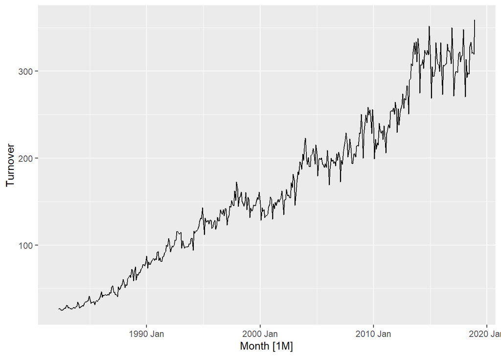

```r
aus_retail %>%
  filter(Industry == "Takeaway food services",
         State == "Queensland") %>%
  autoplot(Turnover)
```

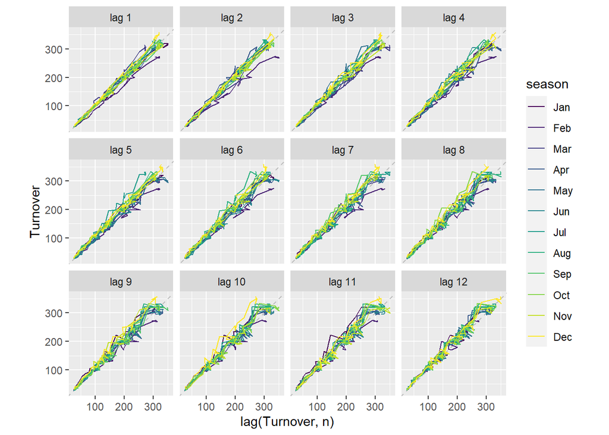

```r
aus_retail %>%
  filter(Industry == "Takeaway food services",
         State == "Queensland") %>%
  gg_lag(lags = 1:12)
```

Below shows 36 months (3 years) of forecast data using snaive which accounts for the seasonality in the data we found above. This does miss the trend data, which a random walk/drift model would capture better I would guess.

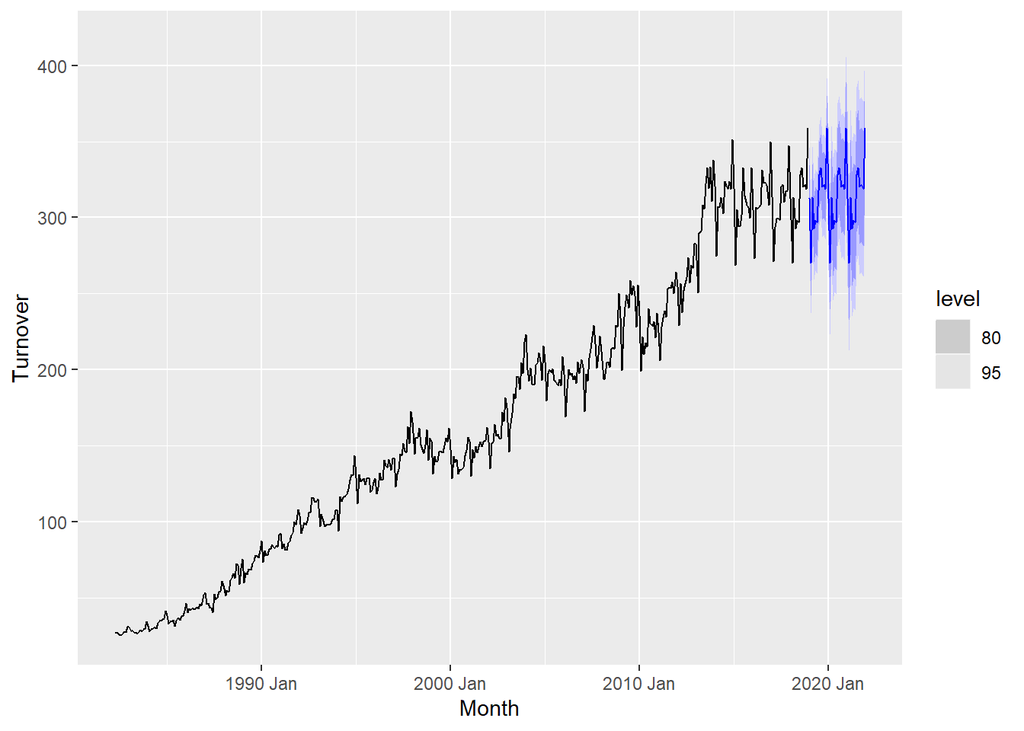

```r
aus_retail %>%
  filter(Industry == "Takeaway food services",
         State == "Queensland") %>%
  model(SNAIVE(Turnover ~ lag("year"))) %>%
  forecast(h = 36) %>%
  autoplot(aus_retail)
```

### Exercise 5.2

#### Use the Facebook stock price (data set gafa_stock) to do the following:

#### Produce a time plot of the series.

Plot of FB `Close` stock price appears to have had an upward trend until mid 2018 when there was sharp drop and then a continuing decrease as time went on.

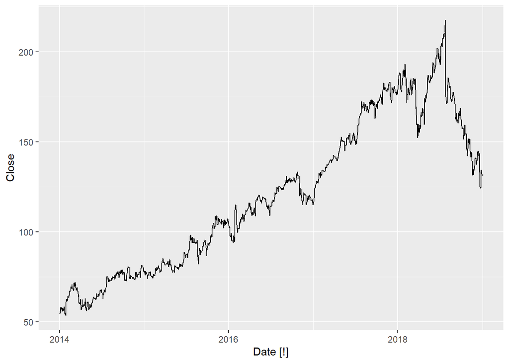

```r
gafa_stock %>%
  filter(Symbol == "FB") %>%
  autoplot(Close)
```

#### Produce forecasts using the drift method and plot them.

As the stock dates were tagged as irregular by this forecasting method, I first had to make a new tsibble that simply numbered the trading days (starting at 1) and reset the index. Once this was recognized as regular I was able to model, forecast and plot below. We see it expects a slight increase, likely due to the overall upward trend for most of the data history.

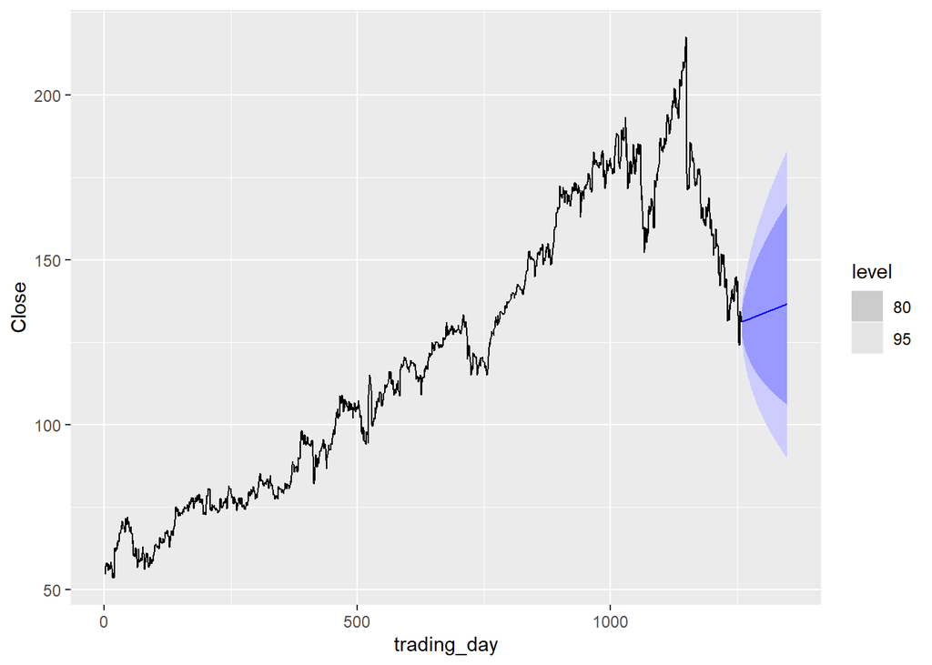

```r
#can't run model with irregular intervals, so need to number the trading day
fb_stock <- gafa_stock %>%
  filter(Symbol == "FB") %>%
  mutate(trading_day = row_number()) %>%
  update_tsibble(index = trading_day, regular = TRUE)

#model, forecast, and plot with drift method
fb_stock %>%
  fill_gaps() %>%
  filter(Symbol == "FB") %>%
  model(RW(Close ~ drift())) %>%
  forecast(h = 90) %>%
  autoplot(fb_stock)
```

#### Show that the forecasts are identical to extending the line drawn between the first and last observations.

After spending some time trying to figure out how to code a line on top of autoplot() between to points, I was able to generate the plot below. Here we see that the predicted values are simply an extension of the line between the first and last observation of the historical data.

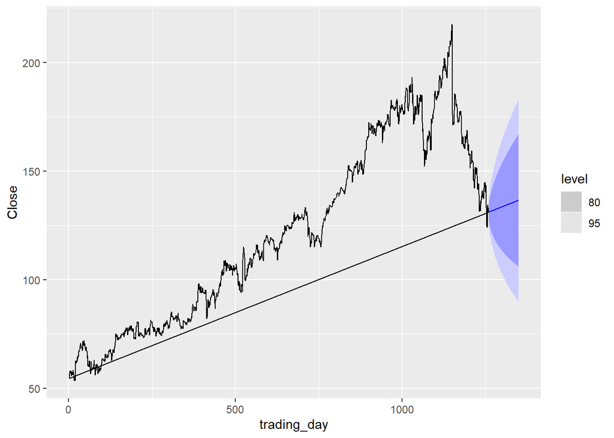

```r
fb_stock %>%
  fill_gaps() %>%
  filter(Symbol == "FB") %>%
  model(RW(Close ~ drift())) %>%
  forecast(h = 90) %>%
  autoplot(fb_stock) +
  geom_segment(aes(x=first(fb_stock$trading_day), y=first(fb_stock$Close),
                   xend=last(fb_stock$trading_day), yend=last(fb_stock$Close)))
```

#### Try using some of the other benchmark functions to forecast the same data set. Which do you think is best? Why?

The seasonal naive below (showing 60 trading days forecast) displays the data continuing in a somewhat straight line other than the lag = 5 I provided attempting to see if there was a 1-week lag. Further, after looking at a gg_lag plot, going up to 20 days (roughly 4 weeks of 5-day trading days) it looks like each log plot is increasingly less correlated, which I presume means as time goes on (lags get bigger) they have less in common with each other. This is not a good one to use for the FB Close stock dataset.

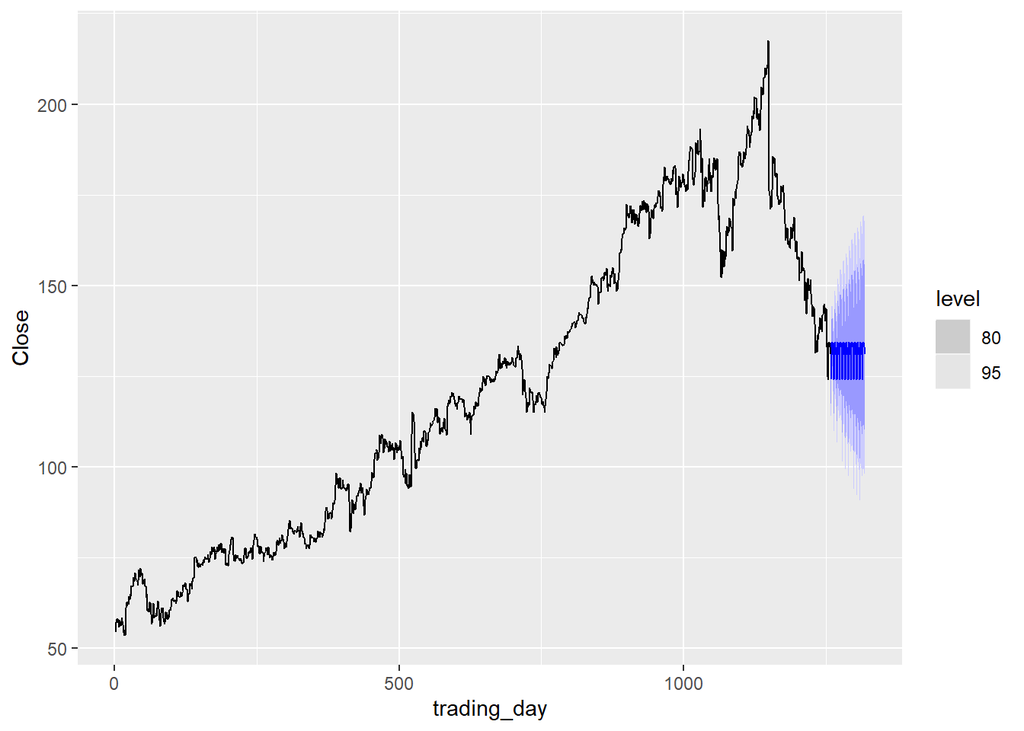

```r
fb_stock %>%
  model(SNAIVE(Close ~ lag(5))) %>%
  forecast(h = 60) %>%
  autoplot(fb_stock)
```

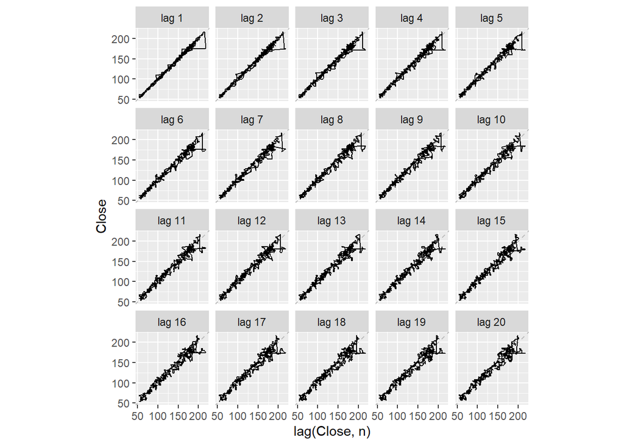

```r
gg_lag(fb_stock, y = Close, lags = 1:20)
```

The plot below looks similar with the forecast remaining close to the last historical data, except with the simple naive (and a lag of 1, as there appears to be no lag) it is a flag line based on the last data point. This is likely the best forecast with what we know.

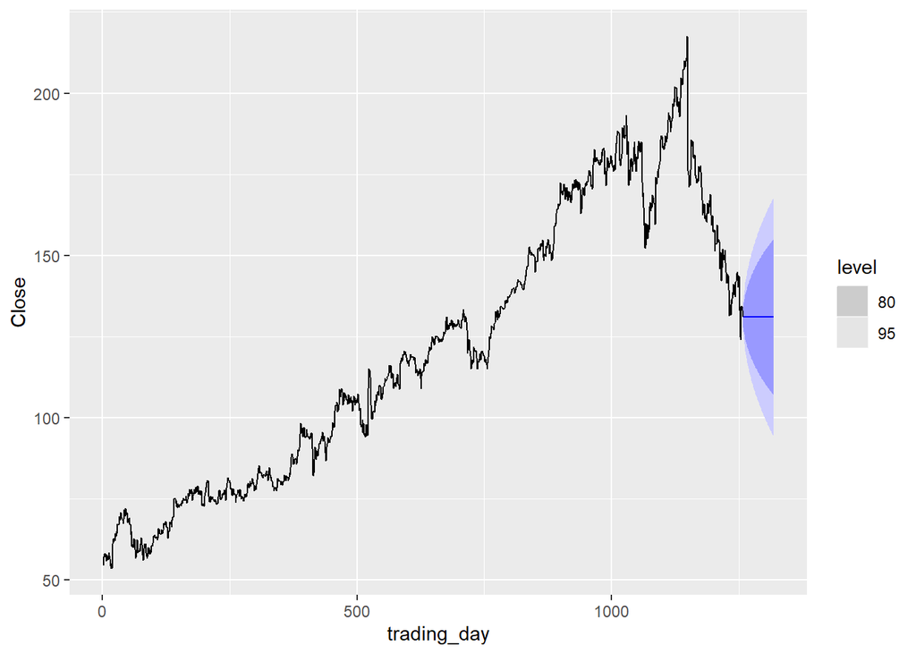

```r
fb_stock %>%
  model(NAIVE(Close ~ lag(1))) %>%
  forecast(h = 60) %>%
  autoplot(fb_stock)
```

Finally, the mean method is very similar to the naive method above, except the forecast is pulled down a bit lower as it accounts the mean of all data points of the historical data. That could or could not be more accurate, likely dependent on what has caused these ups and downs and if any big changes are expected in the near future.

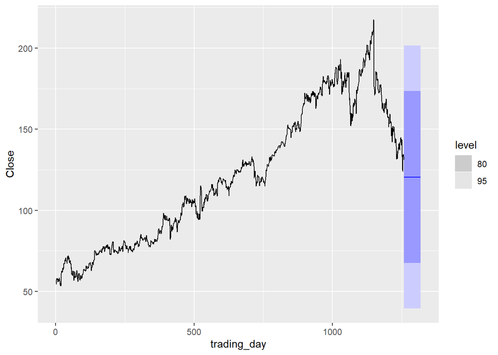

```r
fb_stock %>%
  model(MEAN(Close)) %>%
  forecast(h = 60) %>%
  autoplot(fb_stock)
```